# Arima Models of Uber

In this notebook, I will explore the arima model. First, I will show that the series is not stationary.Then, I will perform the differncing to make it stationary. Afterward, I explore the ACF nad PACF plots to estimate the parameters for the model. Then, I will try a couple of models to find the best model based on minimum AICc value. I will double check result with the auto.arima. I evaluate the model, look at the residuals, and make the forecast.

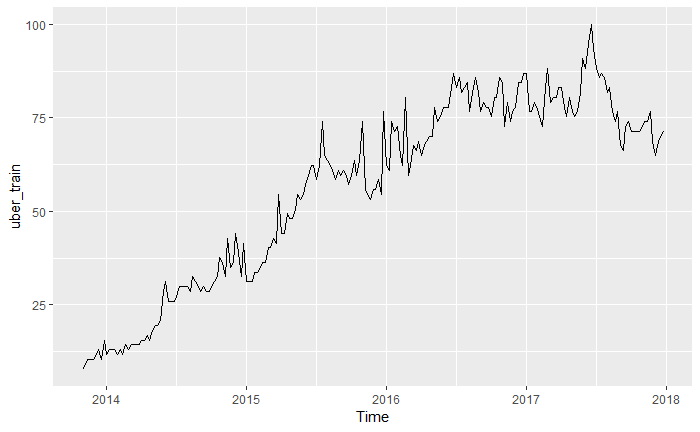

As seen, the location (average) of the series changes over time. This is enough to say that the model is not stationary; however, lets look at the kpss results as well.

```r
uber_train %>% ur.kpss() %>% summary()
```

```
#######################
# KPSS Unit Root Test #
#######################

Test is of type: mu with 4 lags.

Value of test-statistic is: 3.9888

Critical value for a significance level of:
                10pct  5pct 2.5pct  1pct
critical values 0.347 0.463  0.574 0.739
```

The value of the test statistic is significantly larger than all critical values, confirming the series is not stationary. To make it stationary, I will do the differencing. In order to see whether seasonal differing or one or two lag differencing are required, I utilize nsdiffs and ndiffs functions.

```r
print(nsdiffs(uber_train))
```

```
[1] 0
```

```r
print(ndiffs(uber_train))
```

```
[1] 1
```

Since the seasonality is not significant, the seasonal differencing is not necessary. Only lag 1 differing would be enough to make the series stationary. Lets do it and see the kpss results again.

```r
uber_train %>% diff(lag=1) %>% ur.kpss() %>% summary()
```

```
#######################
# KPSS Unit Root Test #
#######################

Test is of type: mu with 4 lags.

Value of test-statistic is: 0.1819

Critical value for a significance level of:
                10pct  5pct 2.5pct  1pct
critical values 0.347 0.463  0.574 0.739
```

As seen, the kpss test confirms that the series is stationary now. Lets now take a look at the ACF and PACF plots to estimate the AR and MA parameters.

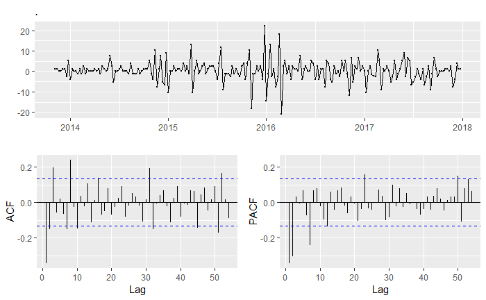

By looking at the plots, following could be understood. 1 - with regards to the seasonality, it seems that there is a spike at lag 52 in the ACF. The seasonal lag values in the PACF are not significant. Therefore, MA(1) might be good.

2 - There are spikes on lags 1 to three in the ACF plot. The PACF values look decreasing gradually, Hence, MA(3) might be a candidate model.

3 - There are two spikes at lags 1 and 2 in the PACF plot and ACF values gradually decrease; hence, THE AR(2) might be a good model.

As a result, I considire these parameters as an inital point and consider several varioations for them. I will explore the following models.

```r
fit <- Arima(uber_train, order = c(0,1,3), seasonal = c(0,0,1))
print(paste('model:', fit$call[3],fit$call[4], 'aicc:', fit$aicc))
```

```
[1] "model: c(0, 1, 3) c(0, 0, 1) aicc: 1267.69624315948"
```

```r
fit <- Arima(uber_train, order = c(0,1,3), seasonal = c(1,0,0))
print(paste('model:', fit$call[3],fit$call[4], 'aicc:', fit$aicc))
```

```
[1] "model: c(0, 1, 3) c(1, 0, 0) aicc: 1266.68527034648"
```

```r
fit <- Arima(uber_train, order = c(1,1,3), seasonal = c(0,0,1))
print(paste('model:', fit$call[3],fit$call[4], 'aicc:', fit$aicc))
```

```
[1] "model: c(1, 1, 3) c(0, 0, 1) aicc: 1268.21451566846"
```

```r
fit <- Arima(uber_train, order = c(0,1,2), seasonal = c(1,0,1))
print(paste('model:', fit$call[3],fit$call[4], 'aicc:', fit$aicc))
```

```
[1] "model: c(0, 1, 2) c(1, 0, 1) aicc: 1270.41510844807"
```

```r
fit <- Arima(uber_train, order = c(2,1,0), seasonal = c(0,0,1))
print(paste('model:', fit$call[3],fit$call[4], 'aicc:', fit$aicc))
```

```
[1] "model: c(2, 1, 0) c(0, 0, 1) aicc: 1264.18354048797"
```

```r
fit <- Arima(uber_train, order = c(2,1,0), seasonal = c(1,0,0))
print(paste('model:', fit$call[3],fit$call[4], 'aicc:', fit$aicc))
```

```
[1] "model: c(2, 1, 0) c(1, 0, 0) aicc: 1263.04298954436"
```

```r
fit <- Arima(uber_train, order = c(2,1,1), seasonal = c(0,0,1))
print(paste('model:', fit$call[3],fit$call[4], 'aicc:', fit$aicc))
```

```
[1] "model: c(2, 1, 1) c(0, 0, 1) aicc: 1265.9417235895"
```

```r
fit <- Arima(uber_train, order = c(2,1,1), seasonal = c(1,0,1))
print(paste('model:', fit$call[3],fit$call[4], 'aicc:', fit$aicc))
```

```
[1] "model: c(2, 1, 1) c(1, 0, 1) aicc: 1265.24199108809"
```

```r
fit <- Arima(uber_train, order = c(1,1,0), seasonal = c(0,0,1))
print(paste('model:', fit$call[3],fit$call[4], 'aicc:', fit$aicc))
```

```
[1] "model: c(1, 1, 0) c(0, 0, 1) aicc: 1282.35152298619"
```

As seen, it turns out that the (2,1,0)(1,0,0) model results in the smallest AICc value. Lets now check the results with the auto.arima model. It may take some time.

```r
auto.arima(uber_train, approximation = F, stepwise = F) %>% summary()
```

```
Series: uber_train
ARIMA(2,1,2)(0,0,1)[52]

Coefficients:
         ar1      ar2      ma1     ma2    sma1
      0.1164  -0.6498  -0.5110  0.6818  0.1609
s.e.  0.1075   0.0962   0.1028  0.0971  0.0666

sigma^2 estimated as 19.39:  log likelihood=-625.13
AIC=1262.27   AICc=1262.67   BIC=1282.52

Training set error measures:
                    ME    RMSE      MAE       MPE     MAPE      MASE        ACF1
Training set 0.3198885 4.34168 3.153475 0.7688104 6.301451 0.1542862 -0.04661574
```

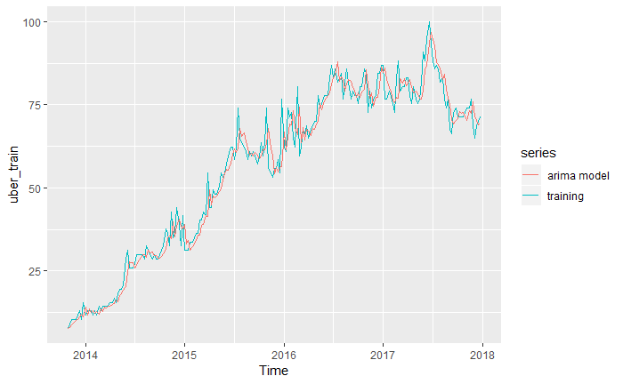

```r
arima_model <- Arima(uber_train, order=c(2,1,0), seasonal = c(1,0,0))
autoplot(uber_train, series='training')+
autolayer(fitted(arima_model), series='arima model')
```

The model seems to be a good fit. Lets’ take a look at the accuracy of the fit on the training data.

```r
accuracy(arima_model)
```

```
                    ME   RMSE      MAE      MPE     MAPE      MASE        ACF1
Training set 0.3848403 4.3876 3.113104 1.020952 6.206389 0.1523111 0.002011349
```

The error metrics are good. Lets’ find the performance of the model on the rolling cross validation sets.

```r
farima <- function(x,h){
    fit <- Arima(x, order=c(2,1,0), seasonal = c(1,0,0))
    return(forecast(fit, h=h))
}
arima_error <- tsCV(uber_train, farima, h=1)
print(rmse(arima_error))
```

```
[1] 4.997186
```

It seems that the model’s performance is fine. Now, let’s take a look at the residuals.

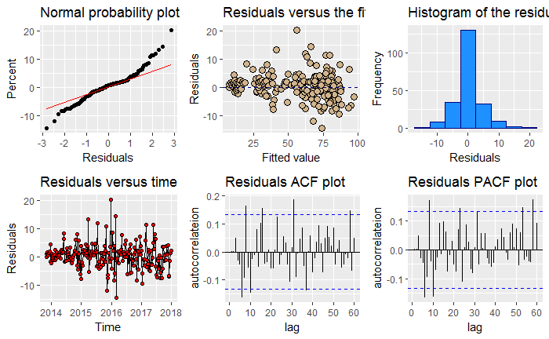

```r
residual_diognostics_plots(arima_model)
```

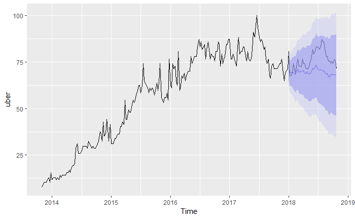

```r
arima_fcst <- forecast(arima_model, h=length(uber_test))
autoplot(uber) +
autolayer(arima_fcst, alpha=0.4)
```

As seen, the model under-predict during the year 2018. Lets’ take a look at the error metrics.

```r
accuracy(arima_fcst, uber)
```

```
                    ME     RMSE      MAE      MPE     MAPE      MASE        ACF1 Theil's U
Training set 0.3848403 4.387600 3.113104 1.020952 6.206389 0.1523111 0.002011349        NA
Test set     6.7062539 8.002027 6.867899 8.466879 8.705458 0.3360173 0.798521214  2.402094
```

The error metrics are not very promising on the testing set. In fact, the frequency of the series is 52 and therefore this is a large frequency for the ARIMA and ETS models. As a result, I believe the seasonal compononet could not be properly explained by the ARIMA model. As a result, I believe dynamic models with inclusion of harmonics or time series decomposition models with ARIMA on seasonally adjusted data may work better. In the next notebook, I will explore the series decomposition models. Stay tuned.